# Change:On Team

# 1. 회귀분석

### 1. 데이터로드 및 모델적합

```r
rm(list=ls())
df <- read.csv("C:/Users/hoyong/Downloads/numeric.csv", fileEncoding = "euc-kr")
Y <- df$총1인가구수
```

### 2. 정규성 및 선형성 확인

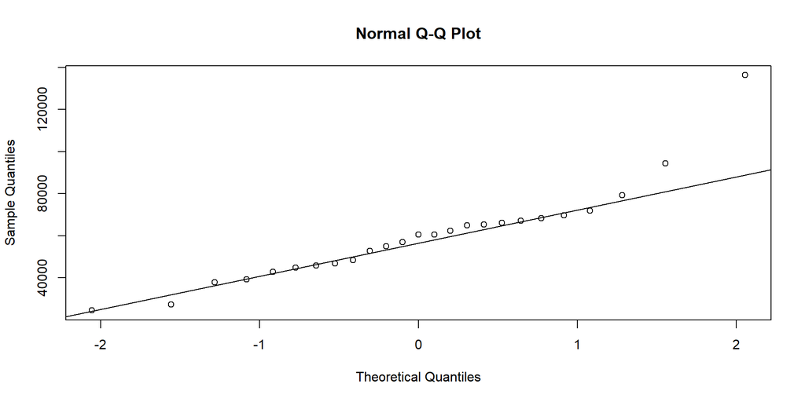

```r
qqnorm(Y)
qqline(Y)
```

```r
shapiro.test(Y)
```

```
##
##  Shapiro-Wilk normality test
##
## data:  Y
## W = 0.88043, p-value = 0.007053
```

```r
library(car)
```

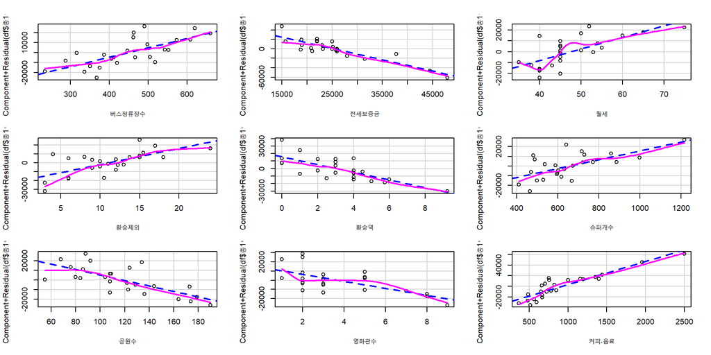

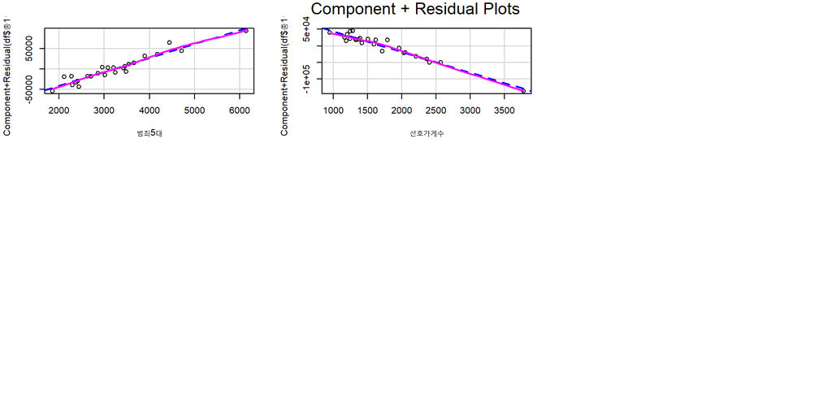

```r
lm <- lm(df$총1인가구수 ~., data = df)
crPlots(lm)
```

y값 변수변환 필요성 있음, 월세, 영화관, 커피 변수변환 필요.

```r
summary(car::powerTransform(Y))
```

```
## bcPower Transformation to Normality
##   Est Power Rounded Pwr Wald Lwr Bnd Wald Upr Bnd
## Y     0.087           0      -0.6994       0.8734
##
## Likelihood ratio test that transformation parameter is equal to 0
##  (log transformation)
##                              LRT df    pval
## LR test, lambda = (0) 0.04683549  1 0.82866
##
## Likelihood ratio test that no transformation is needed
##                            LRT df     pval
## LR test, lambda = (1) 5.258262  1 0.021843
```

p-value = 0.021843 < $\alpha$ 로그변환 유효.

For better interpretation, transform every variables with log-transformation.

### 3. 모델 적합

```r
lm <- lm(log(Y) ~ log(df$월세) + log(df$버스정류장수) + log(df$전세보증금)+ log(df$환승제외) + log(df$환승역+1)  + log(df$공원수) +log(df$영화관) + log(df$커피.음료) + log(df$범죄5대) + log(df$선호가게수), data = df)
summary(lm)
```

```
##
## Call:
## lm(formula = log(Y) ~ log(df$월세) + log(df$버스정류장수) +
##     log(df$전세보증금) + log(df$환승제외) + log(df$환승역 +
##     1) + log(df$공원수) + log(df$영화관) + log(df$커피.음료) +
##     log(df$범죄5대) + log(df$선호가게수), data = df)
##
## Residuals:
##      Min       1Q   Median       3Q      Max
## -0.24371 -0.10226 -0.01787  0.07497  0.37436
##
## Coefficients:
##                      Estimate Std. Error t value Pr(>|t|)
## (Intercept)          10.08989    3.08843   3.267  0.00562 **
## log(df$월세)          0.75207    0.60278   1.248  0.23262
## log(df$버스정류장수)  0.62216    0.23543   2.643  0.01930 *
## log(df$전세보증금)   -1.12627    0.36077  -3.122  0.00750 **
## log(df$환승제외)      0.55008    0.24331   2.261  0.04023 *
## log(df$환승역 + 1)   -0.37439    0.15182  -2.466  0.02719 *
## log(df$공원수)       -0.49595    0.24983  -1.985  0.06708 .
## log(df$영화관)       -0.24668    0.09689  -2.546  0.02330 *
## log(df$커피.음료)     0.55860    0.33638   1.661  0.11901
## log(df$범죄5대)       1.50079    0.38317   3.917  0.00155 **
## log(df$선호가게수)   -1.14343    0.50672  -2.257  0.04055 *
## ---
## Signif. codes:  0 '***' 0.001 '**' 0.01 '*' 0.05 '.' 0.1 ' ' 1
##
## Residual standard error: 0.1913 on 14 degrees of freedom
## Multiple R-squared:  0.8376, Adjusted R-squared:  0.7216
## F-statistic:  7.22 on 10 and 14 DF,  p-value: 0.0005341
```

전체 회귀식 p-value < $\alpha$, 적어도 하나이상의 계수가 0이아님, 즉 회귀식이 유의하다.  
월세가 증가 할 수록 1인가구수가 증가한다고 나와 있으나 유의한 계수가 아니다. 다중공선성을 조금 의심하고 넘어간다.

$R^2_a$ = 0.7216 으로 설명력이 좋은편이다.

### 4. 변수변환된 모델 선형성 확인

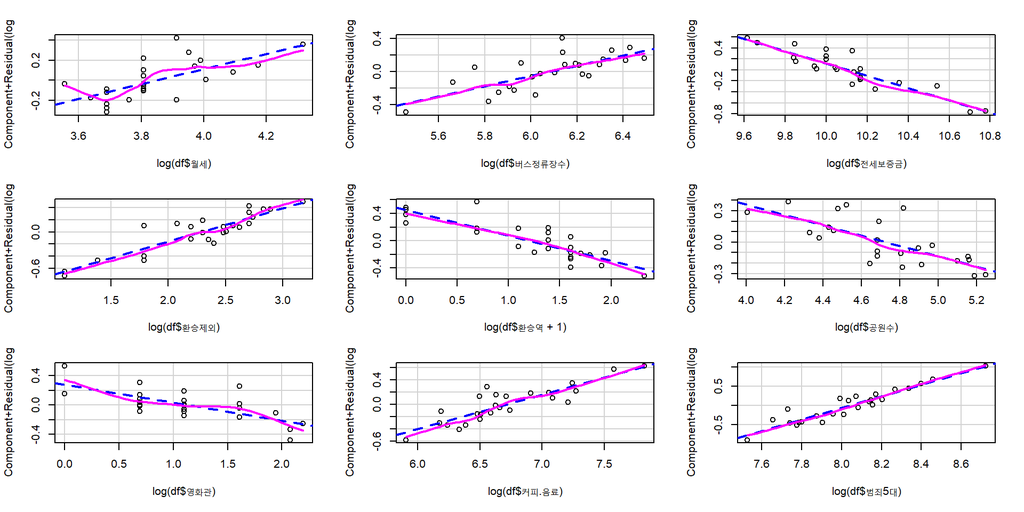

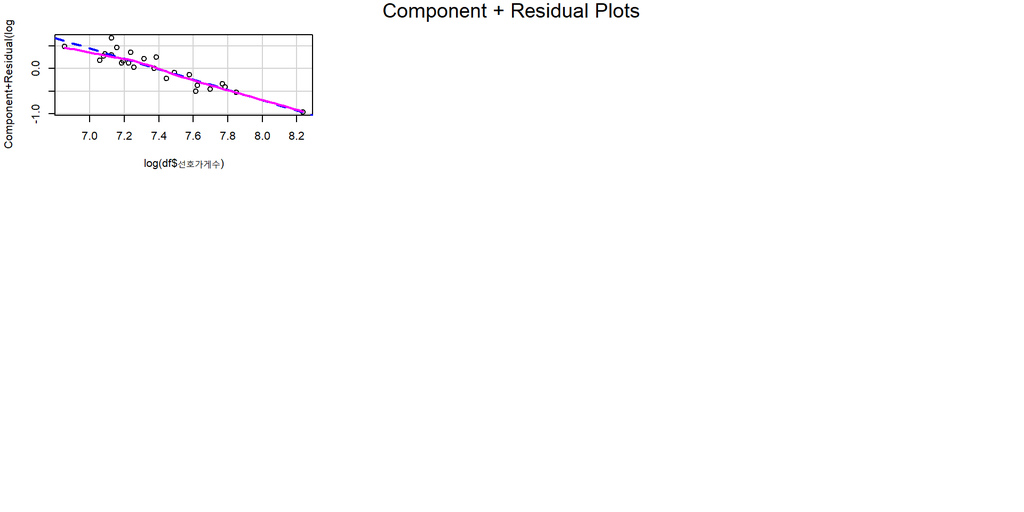

```r
crPlots(lm)
```

변수변환 이후 선형성이 훨씬 좋아졌음을 확인 할 수 있다.

# 2. 잔차검정

### 1. 잔차 정규성검정

$H_0$ : 잔차는 정규분포를 따른다.  
$H_1$ : not $H_0$, $\alpha = 0.05$

```r
shapiro.test(lm$residuals)
```

```
##
##  Shapiro-Wilk normality test
##
## data:  lm$residuals
## W = 0.96135, p-value = 0.442
```

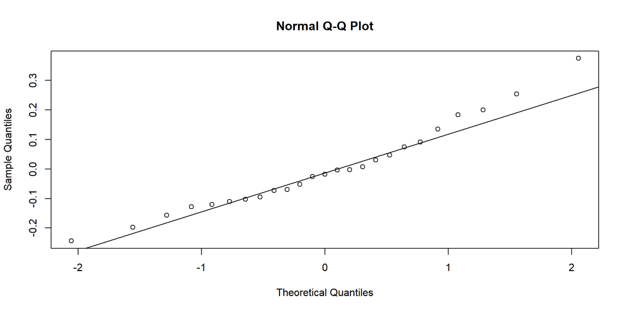

```r
qqnorm(lm$residuals)
qqline(lm$residuals)
```

p-value = 0.442 > $\alpha$, Accept $H_0$.  
qq-plot, shapiro wilk 모두 잔차의 정규성 만족된다고 볼 충분한 근거가 존재.

### 2. 잔차 독립성 검정

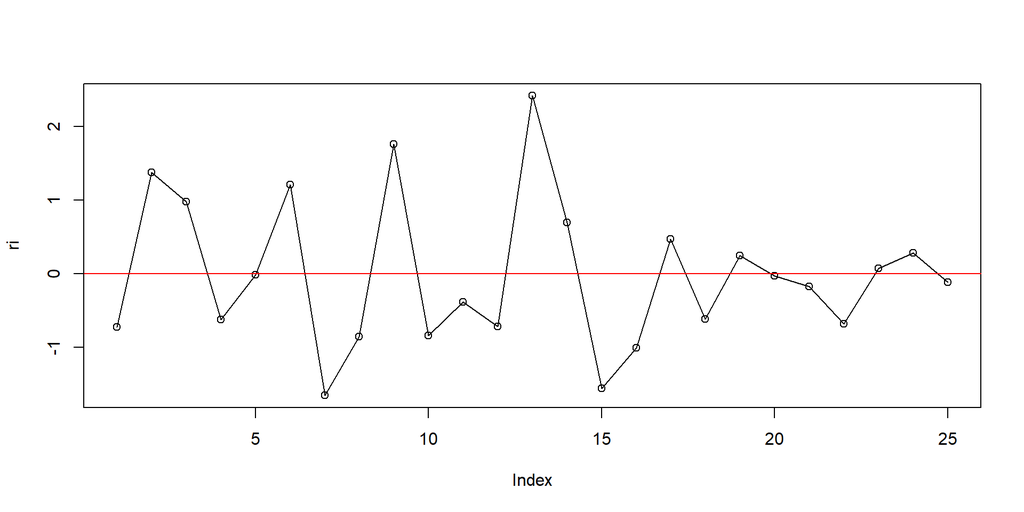

```r
ri <- rstandard(lm)
plot(ri, type='o')
abline(h=0, lty=1, col='red')
```

residual, index plot 확인한 결과 -2, 2 사이 근방에서 랜덤하게 퍼져 있어  
독립성 만족하지만 음의 자기상관이 의심 되어 추가적 검정 실시

### ACF 확인

```r
#acf
rho_hat <- acf(lm$residuals,plot=FALSE)[1]
rho_hat
```

```
##
## Autocorrelations of series 'lm$residuals', by lag
##
##      1
## -0.168
```

### DW-test

```r
library(lmtest)
dwtest(lm, alternative = 'less')
```

```
##
##  Durbin-Watson test
##
## data:  lm
## DW = 2.312, p-value = 0.3122
## alternative hypothesis: true autocorrelation is less than 0
```

p-value = 0.3122 > 0.05 ($\alpha$), Accept $H_0$.  
결과를 종합한 결과 잔차의 독립성은 만족된다고 볼 수 있다.

### 3. 잔차의 등분산성 확인

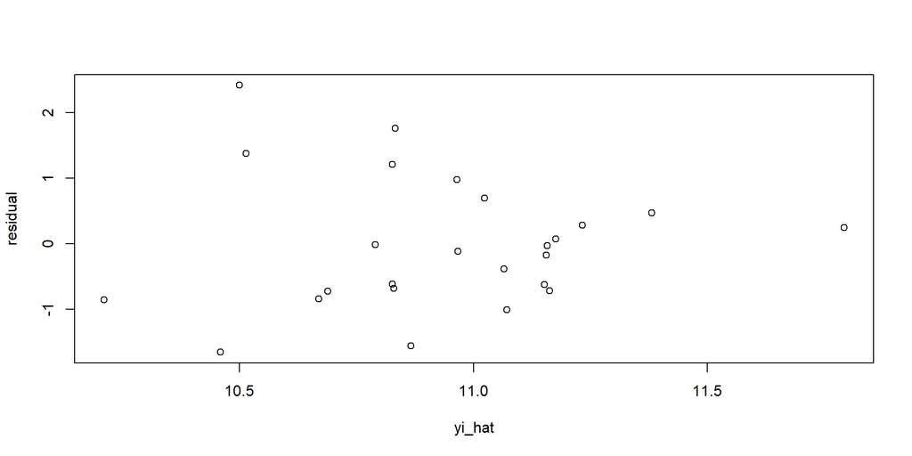

```r
yi_hat <- predict(lm)
residual <- rstandard(lm)
plot(yi_hat, residual)
```

($\hat{y_i}, r_i$) plot 을 확인해본 결과 랜덤하여 잔차의 등분산성 가정이 성립 한다고 볼 수 있다.

# 3. 다중공선성 확인

```r
vif(lm)
```

```
##         log(df$월세) log(df$버스정류장수)   log(df$전세보증금)
##             7.387561             2.310917             6.494553
##     log(df$환승제외)   log(df$환승역 + 1)       log(df$공원수)
##            11.248981             6.690087             4.234671
##       log(df$영화관)    log(df$커피.음료)      log(df$범죄5대)
##             2.160114            15.675207             7.360458
##   log(df$선호가게수)
##            16.852865
```

```r
library(perturb)
colldiag(lm, center = TRUE, scale = TRUE)
```

```
## Condition
## Index    Variance Decomposition Proportions
##            log(df$월세) log(df$버스정류장수) log(df$전세보증금)
## 1    1.000 0.003        0.003                0.003
## 2    1.817 0.009        0.079                0.003
## 3    2.385 0.003        0.059                0.029
## 4    2.718 0.035        0.013                0.021
## 5    3.167 0.008        0.063                0.022
## 6    4.053 0.025        0.433                0.075
## 7    5.271 0.142        0.155                0.115
## 8    7.746 0.141        0.113                0.030
## 9   11.592 0.561        0.007                0.695
## 10  13.074 0.074        0.074                0.008
##    log(df$환승제외) log(df$환승역 + 1) log(df$공원수) log(df$영화관)
## 1  0.002            0.002              0.003          0.007
```

[output cut: 20 more lines]

### 1. 독립변수 다중공선성 확인

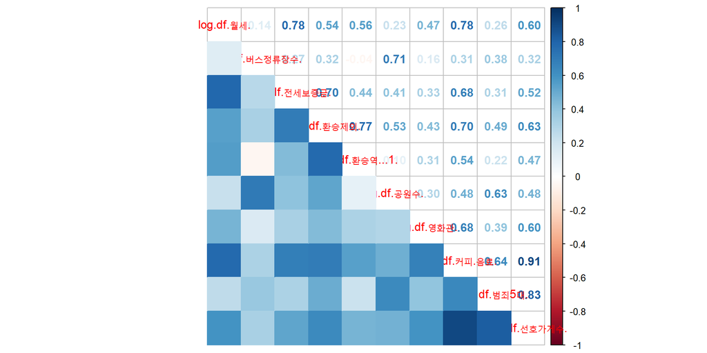

```r
X_matrix <- data.frame(log(df$월세), log(df$버스정류장수), log(df$전세보증금),log(df$환승제외),log(df$환승역+1),log(df$공원수),log(df$영화관),log(df$커피.음료),log(df$범죄5대),log(df$선호가게수))
M <- cor(X_matrix)
library(corrplot)
corrplot.mixed(M, lower="color",upper="number")
```

collinear 한 성질을 가진 columns들이 몇몇 보인다.

# 4. 이상치 탐지

### 1. leverage point 확인

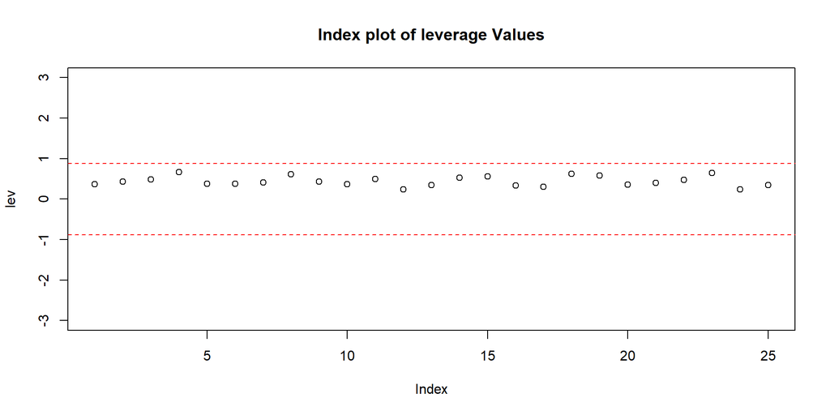

```r
p <- length(lm$coefficients)-1 ; n <- dim(df)[1]
lev <- influence(lm)$hat
reference_value <- 2*(p+1)/n
plot(lev, main='Index plot of leverage Values', ylim= c(-3,3)) # Calculate high leverage and plot lines.
abline(h = c(-reference_value, reference_value), lty=2, col = 'red')
```

high leverage point 없다고 볼 수 있다.

### 2. influential point 확인

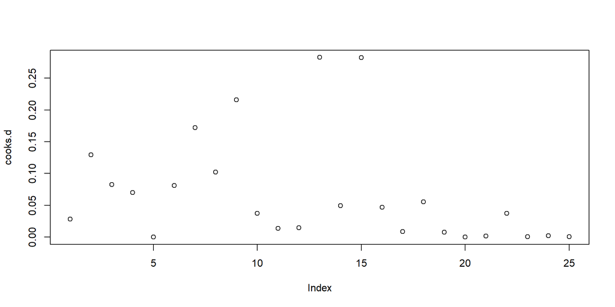

```r
cooks.d <- cooks.distance(lm)
plot(cooks.d)
```

# 5. PCA Regression

```r
pca <- prcomp(X_matrix, center = TRUE, scale = TRUE)
summary(pca)
```

```
## Importance of components:
##                           PC1    PC2     PC3     PC4     PC5     PC6     PC7
## Standard deviation     2.3309 1.2828 0.97714 0.85765 0.73608 0.57516 0.44220
## Proportion of Variance 0.5433 0.1646 0.09548 0.07356 0.05418 0.03308 0.01955
## Cumulative Proportion  0.5433 0.7079 0.80335 0.87691 0.93109 0.96417 0.98372
##                            PC8     PC9    PC10
## Standard deviation     0.30092 0.20109 0.17829
## Proportion of Variance 0.00906 0.00404 0.00318
## Cumulative Proportion  0.99278 0.99682 1.00000
```

```r
lm <- lm(log(Y) ~ pca$x[,1] + pca$x[,2] + pca$x[,3] + pca$x[,4] + pca$x[,5])
summary(lm)
```

```
##
## Call:
## lm(formula = log(Y) ~ pca$x[, 1] + pca$x[, 2] + pca$x[, 3] +
##     pca$x[, 4] + pca$x[, 5])
##
## Residuals:
##      Min       1Q   Median       3Q      Max
## -0.43749 -0.12856 -0.00873  0.17956  0.42964
##
## Coefficients:
##             Estimate Std. Error t value Pr(>|t|)
## (Intercept) 10.93257    0.04997 218.778  < 2e-16 ***
## pca$x[, 1]  -0.02104    0.02188  -0.962    0.348
## pca$x[, 2]   0.19769    0.03976   4.972 8.46e-05 ***
## pca$x[, 3]   0.04741    0.05219   0.908    0.375
## pca$x[, 4]   0.09799    0.05947   1.648    0.116
## pca$x[, 5]   0.10661    0.06929   1.539    0.140
## ---
## Signif. codes:  0 '***' 0.001 '**' 0.01 '*' 0.05 '.' 0.1 ' ' 1
##
## Residual standard error: 0.2499 on 19 degrees of freedom
## Multiple R-squared:  0.6242, Adjusted R-squared:  0.5253
## F-statistic: 6.311 on 5 and 19 DF,  p-value: 0.001304
```

주성분 5개로도 변동의 93%설명 가능하므로 주성분 5개 선택.

### 1. eigen matrix

```r
eigen_matrix <- pca$rotation

co_1 <- c(); co_2 <- c(); co_3 <- c(); co_4 <- c(); co_5 <-c()
for (i in 1:10){
  co_1 <- c(co_1, eigen_matrix[i,1])
  co_2 <- c(co_2, eigen_matrix[i,2])
  co_3 <- c(co_3, eigen_matrix[i,3])
  co_4 <- c(co_4, eigen_matrix[i,4])
  co_5 <- c(co_5, eigen_matrix[i,5])
}
```

$Y_t$ = $\gamma_0$ + $\alpha_1$(-0.3240008$A^s_t$+ -0.1894588$B^s_t$+ -0.3253709 $C^s_{t}$+ -0.361965$D^S_{t}$+ -0.2642302$E^S_{t}$+ -0.2726465$F^S_{t}$
$\qquad$$\qquad$$\;$+ -0.2772605 $G^S_{t}$+ -0.4039255$H^S_{t}$+ -0.304481 $I^S_{t}$+ -0.381251$J^S_{t}$

$\qquad$ $\;$ $\,$ + $\alpha_2$(-0.3269515$A^s_t$ 0.5484535$B^s_t$+ -0.1665467 $C^s_{t}$-0.1060942$D^S_{t}$+ -0.427491$E^S_{t}$+ 0.5006716$F^S_{t}$ $\qquad$$\qquad$$\;$ $\qquad$$\qquad$$\qquad$$\;$ -0.0635855 $G^S_{t}$ -0.075182$H^S_{t}$ +0.3281275 $I^S_{t}$ 0.0502394$J^S_{t}$

$\qquad$ $\;$ $\,$ + $\alpha_3$(-0.150243$A^s_t$ -0.3623229$B^s_t$ -0.4248686$C^s_{t}$ -0.2686007$D^S_{t}$ -0.1481362$E^S_{t}$+ -0.2146497$F^S_{t}$ $\qquad$$\qquad$$\;$ $\qquad$$\qquad$$\qquad$$\;$ +0.487902$G^S_{t}$ +0.1736736$H^S_{t}$ 0.3689943$I^S_{t}$+ 0.3479985$J^S_{t}$

$\qquad$ $\;$ $\,$ + $\alpha_4$(-0.4348827$A^s_t$ -0.1487646$B^s_t$ -0.3197435$C^s_{t}$ + 0.4048708$D^S_{t}$+ 0.5486426$E^S_{t}$+ 0.0633846$F^S_{t}$ $\qquad$$\qquad$$\qquad$$\qquad$$\qquad$$\;$ + -0.3211797$G^S_{t}$ -0.1521536$H^S_{t}$ 0.294851$I^S_{t}$ 0.0657214$J^S_{t}$

$\qquad$ $\;$ $\,$ + $\alpha_5$(0.1770681$A^s_t$+ -0.2812607$B^s_t$+ 0.2752979$C^s_{t}$ + -0.2010219$D^S_{t}$ -0.2421588$E^S_{t}$+ -0.1055411$F^S_{t}$ $\qquad$$\qquad$$\qquad$$\qquad$$\qquad$$\;$-0.6752741$G^S_{t}$ 0.0798377$H^S_{t}$ 0.4137667$I^S_{t}$+ 0.2645539$J^S_{t}$+ $\epsilon$

### 2. Calc Gamma

```r
calc_gamma <- function(k){sum <- 0
for (i in 1:5){
sum <- sum + (eigen_matrix[k,i]*summary(lm)$coefficient[i+1,1]
)}
return(sum)
}
coef_list <- c(calc_gamma(1), calc_gamma(2),calc_gamma(3), calc_gamma(4), calc_gamma(5), calc_gamma(6), calc_gamma(7), calc_gamma(8), calc_gamma(9), calc_gamma(10))
x_mean <- apply(X_matrix, 2, mean)
x_std <- apply(X_matrix, 2, sd)
coef_list
```

```
##  [1] -0.088677694  0.050673510 -0.048203450 -0.007851370 -0.058032735
##  [6]  0.089499208 -0.087066418 -0.004528388  0.161770443  0.069094895
```

$Y_t$ = 10.9325665+ -0.0886777$A^S_t$+ 0.0506735$B^S_t$+ -0.0482035$C^S_{t}$+ -0.0078514$D^S_{t}$+ -0.0580327$E^S_{t}$+ 0.0894992$F^S_{t}$  
$\qquad$ -0.0870664$G^S_{t}$+ -0.0045284$H^S_{t}$+ 0.1617704$I^S_{t}$ 0.0690949$J^S_{t}$ + $\epsilon$.

Transform standardized variables to Original variables. Using $\gamma_jX^S_{ij}$ = $\gamma_jX_{ij}\over s_j$-$\gamma_j\bar{X_{j}}\over s_j$, where $X^S_{ij}$ = $X_{ij}-\bar{X_{j}}\over s_j$.

```r
adj_coef <- c()
coef_slope <- c() # gamma divide by std of x_j
for(i in 1:10){
  coef_slope <- c(coef_slope, coef_list[i]/x_std[i])
  adj_coef <- c(adj_coef, -coef_slope[i]*x_mean[i])
}
coef_slope
```

```
##         log.df.월세. log.df.버스정류장수.   log.df.전세보증금.
##         -0.503515466          0.200928967         -0.174711229
##     log.df.환승제외.   log.df.환승역...1.       log.df.공원수.
##         -0.014582998         -0.087209365          0.278194324
##       log.df.영화관.    log.df.커피.음료.      log.df.범죄5대.
##         -0.146960363         -0.009850595          0.584966420
##   log.df.선호가게수.
##          0.218358269
```

### 3. 원변수 변환

```r
intercept <- lm$coefficient[1] + sum(adj_coef)
intercept
```

```
## (Intercept)
##    6.154516
```

$Y_t$ = 6.1545162+ -0.5035155$A_t$+ 0.200929$B_t$+ -0.1747112$C_{t}$+ -0.014583$D_{t}$+ -0.0872094$E_{t}$  
$\qquad$+ 0.2781943$F_{t}$ -0.1469604$G_{t}$+ -0.0098506$H_{t}$+ 0.5849664$I_{t}$ 0.2183583$J_{t}$ + $\epsilon$.